# Pause to diagram

### Heads up!

*Pause*. You are about to encounter something which, though not difficult to grasp, requires that you to focus on it for a hot second, if you’ve never encountered it before. An analogous level of difficulty would be learning how to diagram a sentence. Some people learn this in grade-school, some never encounter the task at all. It’s not *“hard”* material, and you can be excellent at sentences (writing, reading—the works), and not have the foggiest clue how to diagram one. Basically, it’s something that’s non-obvious, if new.

Frankly, sentence diagramming is slightly more confusing, for my money. For the literate, English-speaking reader, simple sentences are easy to parse (*e.g.* subject and predicate; interrogative sentences, direct objects).

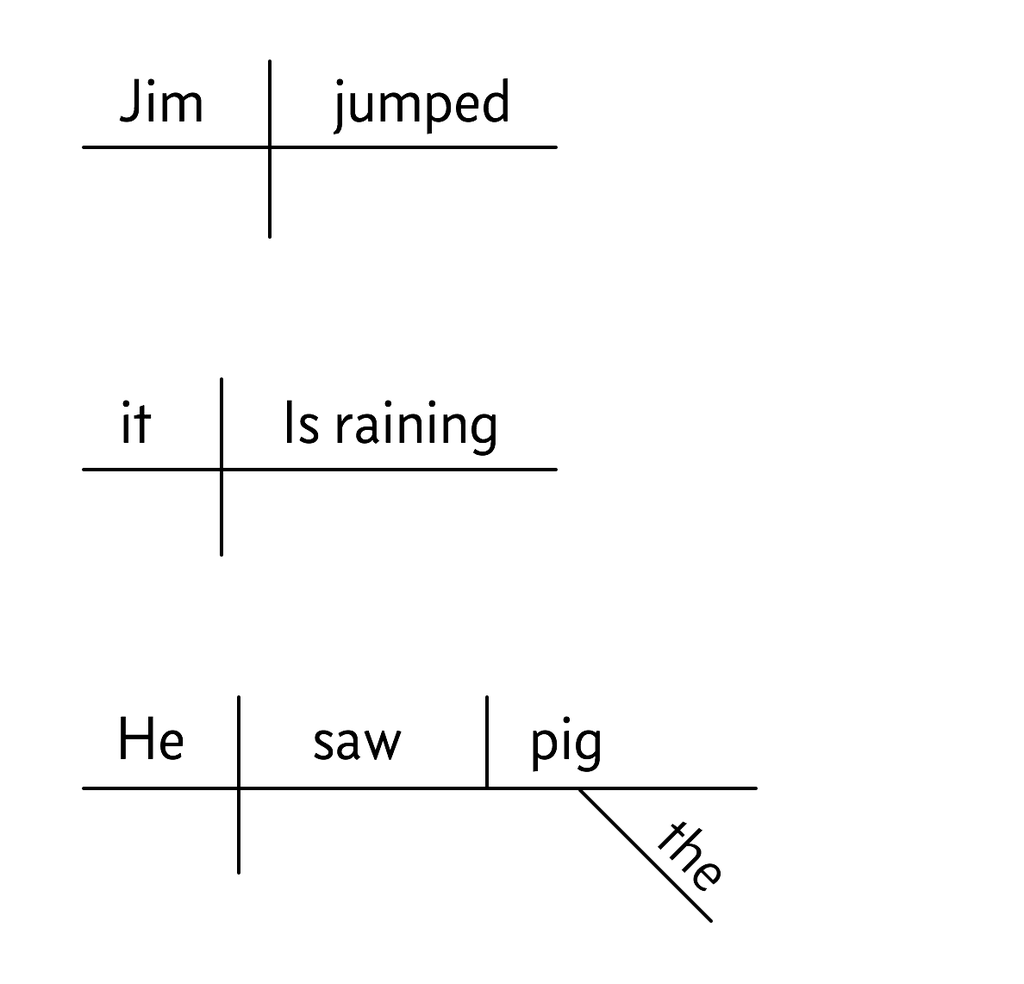

But reading is different from knowing the rules that govern such a diagram.

[figure not shown]

What’s more, things get fairly complicated when we examine the types of sentences we tend to actually use in real life (you don’t need to know how to diagram a relative clause or even what one is in order to speak them).

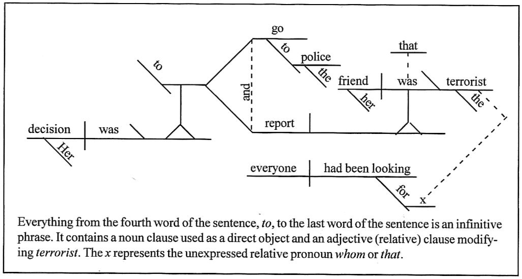

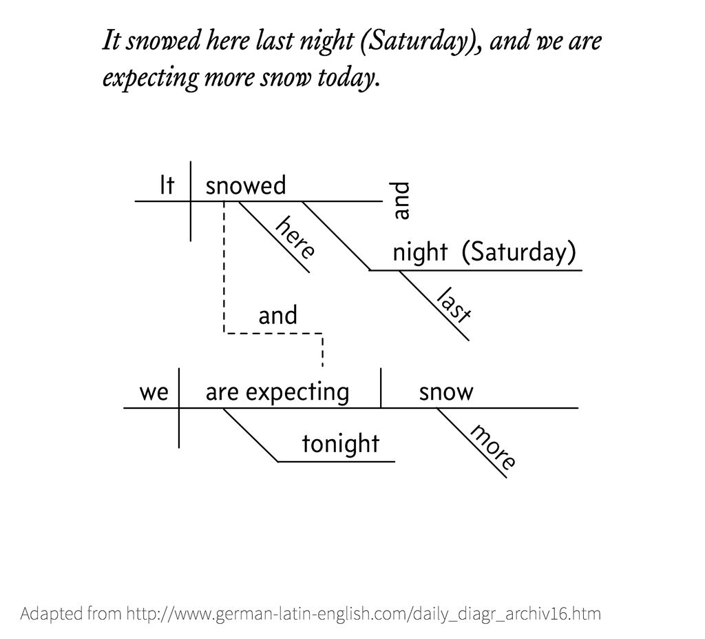

Like, you kow how to read this sentence, but do you know how to break it down into a sentence diagram? I didn’t (hence my adapting it from [Pop Chart Lab’s](https://www.popchartlab.com/) super cool first-line-of-novels-sentence-diagram poster).

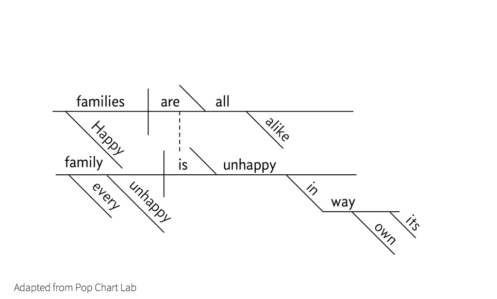

How about the opening line from George Orwell’s *1984*?

[figure not shown]

And here’s a seemingly simple one, that’s actually a bit trickier than one might expect:

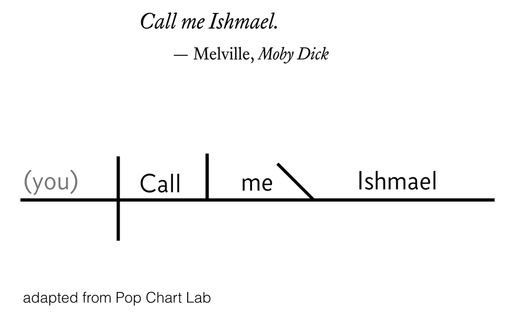

Sometimes you’re not sure how to read the sentence based on looking at the diagram—language is just weird like that:

[figure not shown]

## The Gettysburg Address[^1]

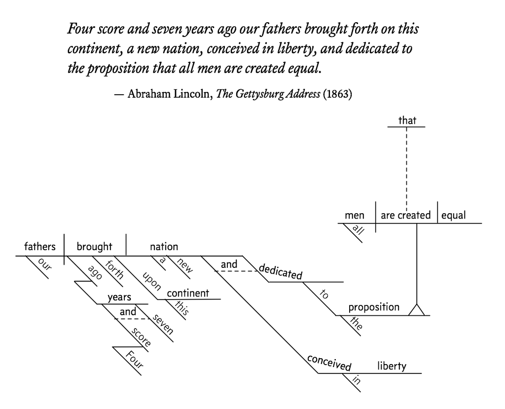

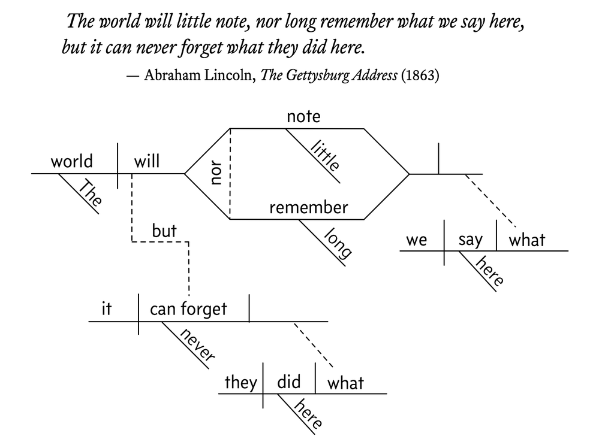

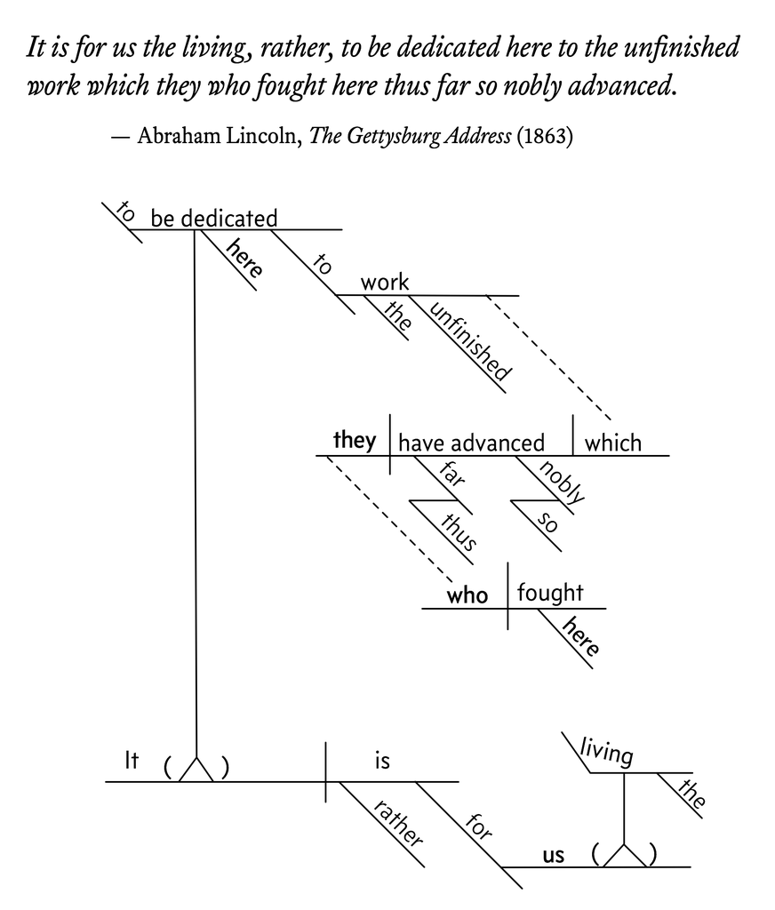

## Back to the AST

Sentence parse trees are closer in form to abstrct syntax trees (ASTs) than the Reed-Kellogg diagrams explored, above.

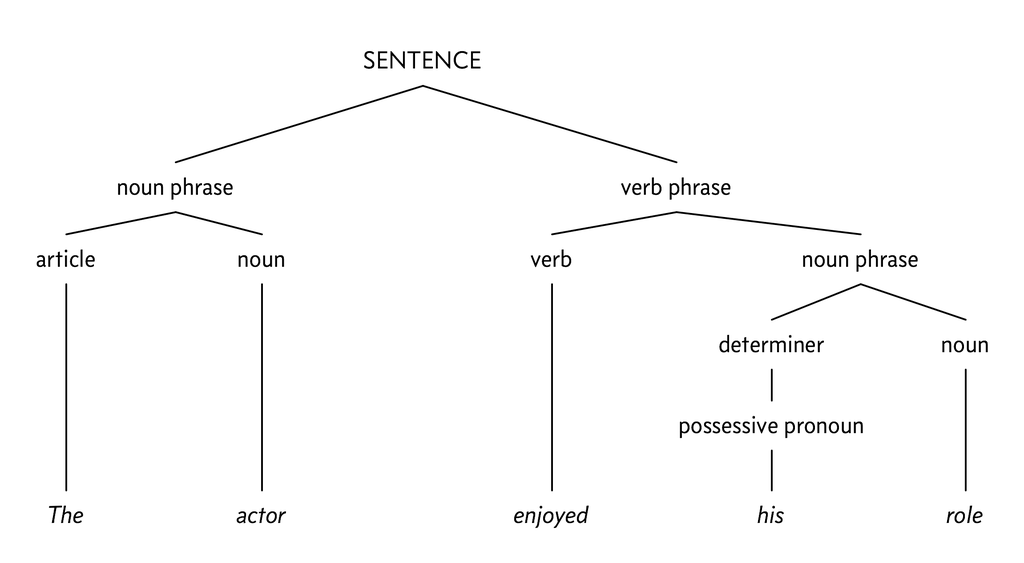

### Prefix-ify

Here is a very simple example of “prefixifying,” if we allow (for the moment) that `+` and `sum()` are one and the same.

```r
8 + 3
```

```
#> [1] 11
```

```r
sum(8, 3)
```

```
#> [1] 11
```

Turns out, there’s a way to do this for any infix function, even if you don’t have an equivalent function handy: add backticks ``.

```r
`+`(8, 3)
```

```
#> [1] 11
```

OK, let’s mix it up a little bit. What if there are two infix operators?

```r
y <- x * 10
```

As Shannon Sharpe might say, *“that ain’t no problem!”*

```r
`<-`(y, `*`(x, 10))
```

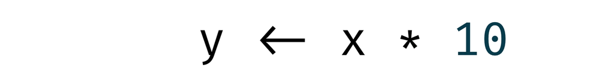

OK, so what about *precedence*?

The example used in [Advanced R](https://adv-r.hadley.nz/expressions.html#naming-conventions) is actually quite similar to another grammatical favourite: the Oxford comma.

First, the R example: What does `1 + 2 * 3` yield? Do you get `9` (i.e. `(1 + 2) * 3`), or `7` (i.e. `1 + (2 * 3)`)?

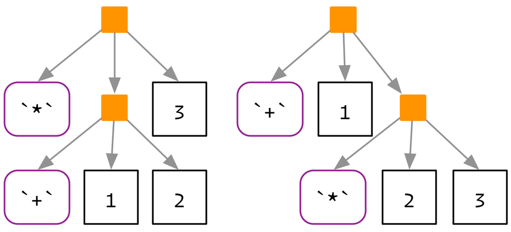

For our sentence diagram, we want to know if we have a compound object (consisting of: rhinoceri, Washington, Lincoln), or if Washington and Lincoln are an appositive noun clause.

[figure not shown]

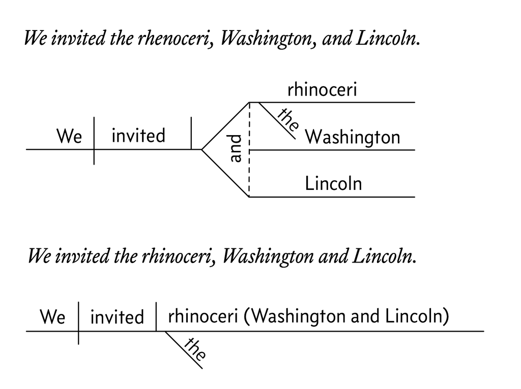

## Definition-worthy

- **Symbol**
- **Name**
- **Value**
- **Expression**
- **Operation**
- **Result**
- **Evaluation**
- **Constant**
- **Variable**
- **Quoted expression**
- **Call**
- **Unquoting**
- **Infix call**
- **Prefix call**
- **Abstract syntax tree**
- **Parse tree**
- **Promise**
- **Argument**
- **Argument name**
- **Named argument**
- **Special forms**
- **Operator precedence**
- **Expression object**
- **Control-flow operators**
- **Reserved words**
- **Lazy evaluation**
- **Eager evaluation**
- **Closure**
- **Quosure**
- **Parse**
- **Deparse**
- **Quotation**
- **Quasiquotation**
- **Empty symbol**
- **Macros**
- **Quoted argument**
- **Data mask**
- **Homoiconicity**

## *Differentia*

### Expressions and Expression Objects

### Referential vs Value Semantics

### Execution Environment vs Caller Environment

### Package Environment vs Namespace Environment

### Delayed Bindings vs Active Bindings

### Evaluating vs Parsing

e.g. see lionel’s reference [here](https://community.rstudio.com/t/a-difference-between-tidyeval-and-substitute-when-the-promise-is-already-evaluated/15480/6)

### Direct vs Indirect References

[^1]: http://www.german-latin-english.com/diagramgettysburg.htm